# Case Study: How Does a Bike-Share Navigate Speedy Success?

Athena Pelfrey

June 23, 2023

# Introduction

This case study was based on an assignment in the Coursera course *Google Data Analytics Capstone: A Complete Case Study*.

**About the Company:** In 2016, Cyclistic launched a successful bike-share offering. Since then, the program has grown to a fleet of 5,824 bicycles that are geotracked and locked into a network of 692 stations across Chicago. The bikes can be unlocked from one station and returned to any other station in the system anytime.

**Company Goal:** Design marketing strategies aimed at converting casual riders into annual members.

**Questions:** Three questions will guide the future marketing program:

1. How do annual members and casual riders use Cyclistic bikes differently?
2. Why would casual riders buy Cyclistic annual memberships?
3. How can Cyclistic use digital media to influence casual riders to become members?

**Task:** Produce a report with the following deliverables to answer the first question.

1. A clear statement of the business task
2. A description of all data sources used
3. Documentation of any cleaning or manipulation of data
4. A summary of your analysis
5. Supporting visualizations and key findings
6. Your top three recommendations based on your analysis

# Data Importing and Cleaning

Steps:

- Import data for 2019
- Rename columns for consistency
- Change data types for consistency
- Combine datasets to a single dataframe
- Add new columns for month, day, hour, and day_of_week
- Filter out trips longer than 24 hours

Here is a quick look at this dataset.

| trip_id | started_at | ended_at | bike_id | trip_duration | start_station_id | start_station_name | end_station_id | end_station_name | user_type | gender | birth_year | year | month | day | hour | day_of_week |
| --- | --- | --- | --- | --- | --- | --- | --- | --- | --- | --- | --- | --- | --- | --- | --- | --- |
| 21742443 | 2019-01-01 00:04:37 | 2019-01-01 00:11:07 | 2167 | 00:06:30 | 199 | Wabash Ave & Grand Ave | 84 | Milwaukee Ave & Grand Ave | Member | Male | 1989 | 2019 | 01 | 01 | 00 | Tuesday |
| 21742444 | 2019-01-01 00:08:13 | 2019-01-01 00:15:34 | 4386 | 00:07:21 | 44 | State St & Randolph St | 624 | Dearborn St & Van Buren St (*) | Member | Female | 1990 | 2019 | 01 | 01 | 00 | Tuesday |
| 21742445 | 2019-01-01 00:13:23 | 2019-01-01 00:27:12 | 1524 | 00:13:49 | 15 | Racine Ave & 18th St | 644 | Western Ave & Fillmore St (*) | Member | Female | 1994 | 2019 | 01 | 01 | 00 | Tuesday |
| 21742446 | 2019-01-01 00:13:45 | 2019-01-01 00:43:28 | 252 | 00:29:43 | 123 | California Ave & Milwaukee Ave | 176 | Clark St & Elm St | Member | Male | 1993 | 2019 | 01 | 01 | 00 | Tuesday |
| 21742447 | 2019-01-01 00:14:52 | 2019-01-01 00:20:56 | 1170 | 00:06:04 | 173 | Mies van der Rohe Way & Chicago Ave | 35 | Streeter Dr & Grand Ave | Member | Male | 1994 | 2019 | 01 | 01 | 00 | Tuesday |
| 21742448 | 2019-01-01 00:15:33 | 2019-01-01 00:19:09 | 2437 | 00:03:36 | 98 | LaSalle St & Washington St | 49 | Dearborn St & Monroe St | Member | Female | 1983 | 2019 | 01 | 01 | 00 | Tuesday |

Quick summaries of data.

```
   trip_id            started_at
 Length:3818004     Min.   :2019-01-01 00:04:37.00
 Class :character   1st Qu.:2019-05-29 15:49:26.50
 Mode  :character   Median :2019-07-25 17:50:54.00
                    Mean   :2019-07-19 21:47:37.11
                    3rd Qu.:2019-09-15 06:48:05.75
                    Max.   :2019-12-31 23:57:17.00

    ended_at                        bike_id          trip_duration
 Min.   :2019-01-01 00:11:07.00   Length:3818004     Length:3818004
 1st Qu.:2019-05-29 16:09:28.25   Class :character   Class1:hms
 Median :2019-07-25 18:12:23.00   Mode  :character   Class2:difftime
 Mean   :2019-07-19 22:11:47.56                      Mode  :numeric
 3rd Qu.:2019-09-15 08:30:13.25
 Max.   :2020-01-21 13:54:35.00

 start_station_id start_station_name end_station_id  end_station_name
 Min.   :  1.0    Length:3818004     Min.   :  1.0   Length:3818004
 1st Qu.: 77.0    Class :character   1st Qu.: 77.0   Class :character
 Median :174.0    Mode  :character   Median :174.0   Mode  :character
 Mean   :201.7                       Mean   :202.6
 3rd Qu.:289.0                       3rd Qu.:291.0
 Max.   :673.0                       Max.   :673.0

  user_type            gender            birth_year         year
 Length:3818004     Length:3818004     Min.   :1759     Length:3818004
 Class :character   Class :character   1st Qu.:1979     Class :character
 Mode  :character   Mode  :character   Median :1987     Mode  :character
                                       Mean   :1984
                                       3rd Qu.:1992
                                       Max.   :2014
                                       NA's   :538751
    month               day                hour
 Length:3818004     Length:3818004     Length:3818004
 Class :character   Class :character   Class :character
 Mode  :character   Mode  :character   Mode  :character




 day_of_week
 Length:3818004
 Class :character
 Mode  :character
```

Retrieve statistics for **trip duration** grouped by user type.

| column | V1 | V2 |
| --- | --- | --- |
| user_type | Casual | Member |
| count | 880637 | 2937367 |
| mean | 00:57:00.885729 | 00:14:19.383275 |
| median | 00:25:49 | 00:09:48 |
| min | 00:01:01 | 00:01:01 |
| max | 2952:20:00 | 2515:43:53 |

Filter out all trips lasting longer than 24 hours.

| Total.Trips | Trips.less.24.hrs | Percentage |
| --- | --- | --- |
| 2937367 | 2936866 | 0.9998294 |
| 880637 | 879290 | 0.9984704 |

Summarize Trip Duration for Filtered data

| column | V1 | V2 |
| --- | --- | --- |
| user_type | Casual | Member |
| count | 879290 | 2936866 |
| mean | 00:39:25.535000 | 00:12:55.632406 |
| median | 00:25:47 | 00:09:48 |
| min | 00:01:01 | 00:01:01 |
| max | 24:00:00 | 23:59:45 |

# Data Analysis: Day of Week

Retrieve statistics for **number of rides** and **trip duration** grouped by **user type** and **day of week**.

| day_of_week | user_type | number_of_rides | mean | median | min | max |
| --- | --- | --- | --- | --- | --- | --- |
| Sunday | Casual | 169941 | 00:41:19.764712 | 00:26:58 | 00:01:01 | 23:57:59 |
| Sunday | Member | 256191 | 00:14:13.309753 | 00:10:32 | 00:01:01 | 23:40:22 |
| Monday | Casual | 101356 | 00:39:17.859653 | 00:25:54 | 00:01:01 | 24:00:00 |
| Monday | Member | 458714 | 00:12:38.249465 | 00:09:40 | 00:01:01 | 23:53:04 |
| Tuesday | Casual | 88495 | 00:37:34.297215 | 00:24:00 | 00:01:01 | 23:50:37 |
| Tuesday | Member | 496951 | 00:12:34.965912 | 00:09:39 | 00:01:01 | 23:58:04 |
| Wednesday | Casual | 89601 | 00:36:40.723586 | 00:23:34 | 00:01:01 | 23:46:47 |
| Wednesday | Member | 494205 | 00:12:37.352769 | 00:09:42 | 00:01:01 | 22:39:18 |
| Thursday | Casual | 101203 | 00:37:23.258599 | 00:23:57 | 00:01:01 | 23:50:58 |
| Thursday | Member | 486837 | 00:12:38.466339 | 00:09:39 | 00:01:01 | 23:59:45 |

[output cut: 4 more lines]

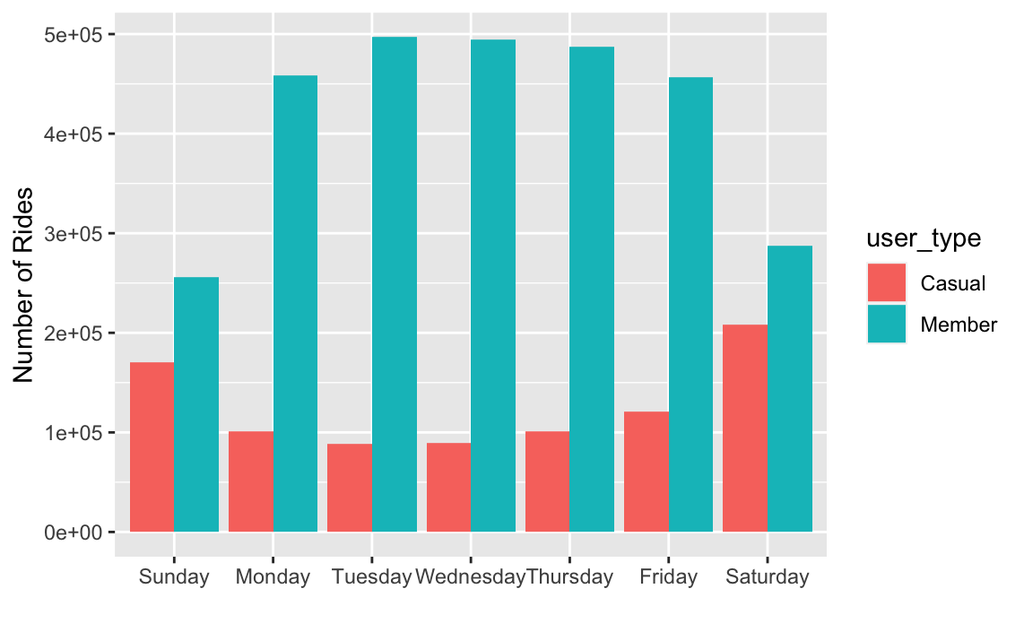

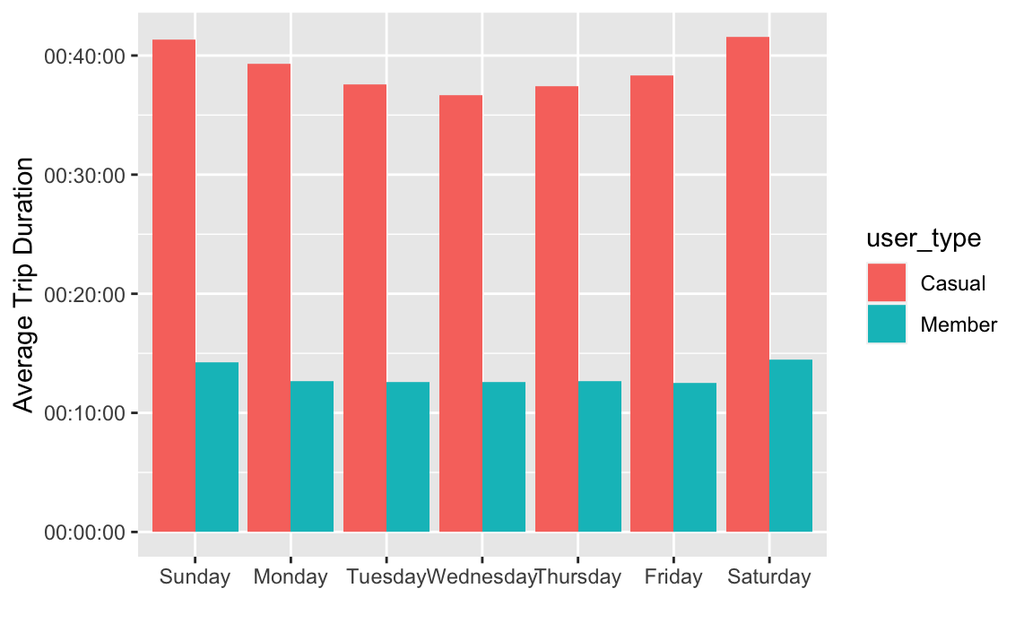

# Data Analysis: Time of Year

Retrieve statistics for **number of rides** and **trip duration** grouped by **user type** and **month**.

| month | user_type | number_of_rides | mean | median | min | max |
| --- | --- | --- | --- | --- | --- | --- |
| 01 | Casual | 4591 | 00:33:37.229580 | 00:21:46 | 00:01:01 | 21:26:25 |
| 01 | Member | 98601 | 00:11:27.313506 | 00:08:20 | 00:01:01 | 23:53:04 |
| 02 | Casual | 2627 | 00:29:20.849638 | 00:17:41 | 00:01:01 | 22:28:04 |
| 02 | Member | 93522 | 00:11:13.513494 | 00:08:07 | 00:01:01 | 23:20:02 |
| 03 | Casual | 15877 | 00:36:44.612521 | 00:24:32 | 00:01:01 | 23:29:49 |
| 03 | Member | 149659 | 00:11:15.736955 | 00:08:31 | 00:01:01 | 22:44:20 |
| 04 | Casual | 47669 | 00:40:51.636724 | 00:27:58 | 00:01:01 | 23:57:05 |
| 04 | Member | 217531 | 00:12:28.176637 | 00:09:26 | 00:01:01 | 23:48:24 |
| 05 | Casual | 81507 | 00:41:35.017741 | 00:27:51 | 00:01:01 | 23:47:06 |
| 05 | Member | 285793 | 00:13:14.101077 | 00:09:59 | 00:01:01 | 23:59:45 |

[output cut: 14 more lines]

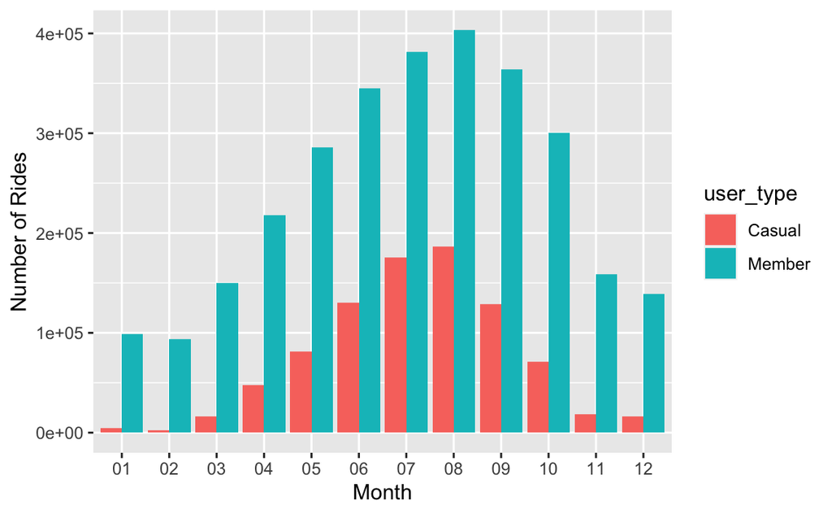

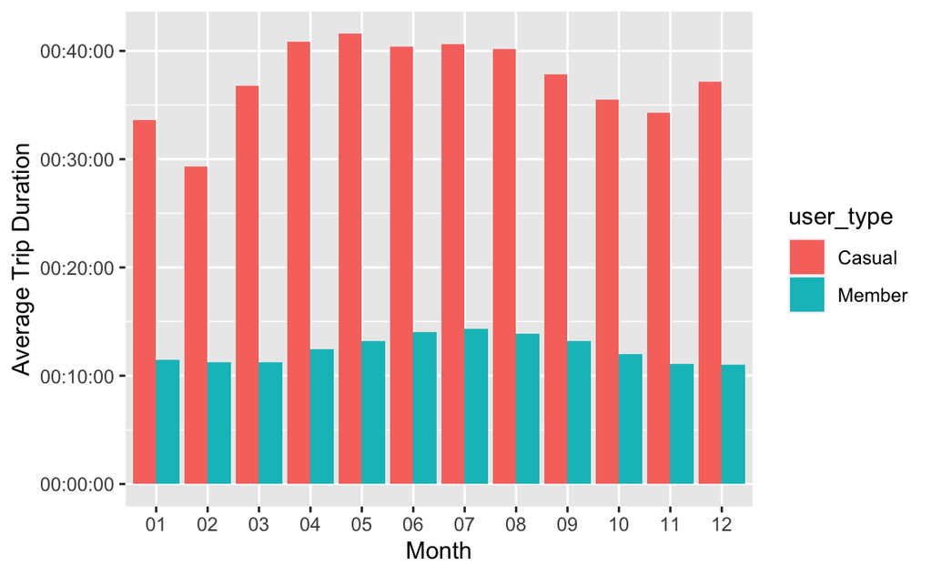

# Data Analysis: Time of Day

Retrieve statistics for **number of rides** and **trip duration** grouped by **user type** and **hour of the day**.

| hour | user_type | number_of_rides | mean | median | min | max |
| --- | --- | --- | --- | --- | --- | --- |
| 00 | Casual | 8179 | 00:39:12.734809 | 00:21:46.0 | 00:01:04 | 22:51:57 |
| 00 | Member | 15867 | 00:13:47.929917 | 00:09:16.0 | 00:01:01 | 22:53:05 |
| 01 | Casual | 5355 | 00:40:12.022409 | 00:22:34.0 | 00:01:34 | 22:22:49 |
| 01 | Member | 9029 | 00:13:35.584229 | 00:09:04.0 | 00:01:01 | 21:32:02 |
| 02 | Casual | 3313 | 00:40:04.318744 | 00:20:52.0 | 00:01:12 | 21:18:45 |
| 02 | Member | 5326 | 00:13:29.299850 | 00:09:20.0 | 00:01:02 | 13:04:30 |
| 03 | Casual | 1908 | 00:41:55.810797 | 00:20:42.5 | 00:01:09 | 19:11:12 |
| 03 | Member | 3680 | 00:12:51.178261 | 00:09:21.0 | 00:01:03 | 10:11:07 |
| 04 | Casual | 1167 | 00:38:52.353899 | 00:17:20.0 | 00:01:59 | 22:23:58 |
| 04 | Member | 6614 | 00:11:03.839734 | 00:07:38.0 | 00:01:06 | 16:04:49 |

[output cut: 38 more lines]

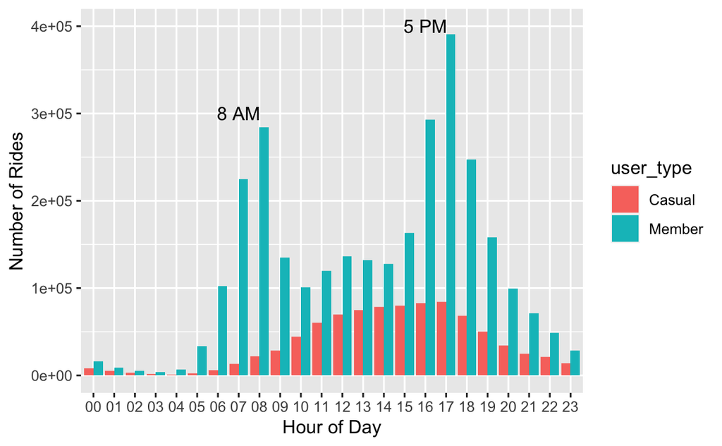

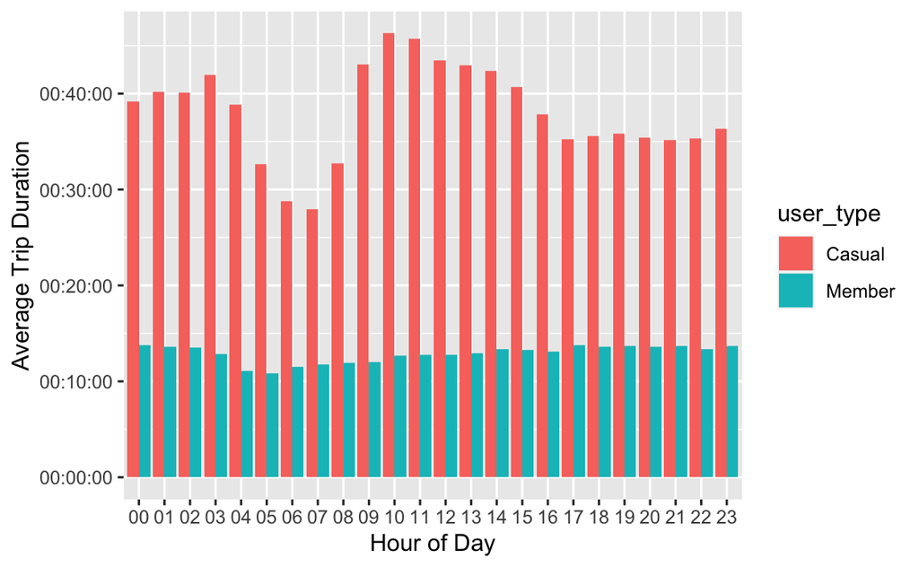